title: “Exploring the BRFSS data” output: html_document: fig_height: 4 highlight: pygments theme: spacelab —

## Setup

### Load packages

```r
library(ggplot2)
library(dplyr)
library(statsr)
```

### Load data

Make sure your data and R Markdown files are in the same directory. When loaded your data file will be called `brfss2013`. Delete this note when before you submit your work.

```r
load("~/4tiY2fqCQa-YmNn6gnGvzQ_1e7320c30a6f4b27894a54e2de50a805_brfss2013.RData")
```

```r
str(brfss2013)
```

```
## 'data.frame':    491775 obs. of  330 variables:
##  $ X_state  : Factor w/ 55 levels "0","Alabama",..: 2 2 2 2 2 2 2 2 2 2 ...
##  $ fmonth   : Factor w/ 12 levels "January","February",..: 1 1 1 1 2 3 3 3 4 4 ...
##  $ idate    : int  1092013 1192013 1192013 1112013 2062013 3272013 3222013 3042013 4242013 4242013 ...
##  $ imonth   : Factor w/ 12 levels "January","February",..: 1 1 1 1 2 3 3 3 4 4 ...
##  $ iday     : Factor w/ 31 levels "1","2","3","4",..: 9 19 19 11 6 27 22 4 24 24 ...
##  $ iyear    : Factor w/ 2 levels "2013","2014": 1 1 1 1 1 1 1 1 1 1 ...
##  $ dispcode : Factor w/ 2 levels "Completed interview",..: 1 1 1 1 1 1 1 1 1 1 ...
##  $ seqno    : int  2013000580 2013000593 2013000600 2013000606 2013000608 2013000630 2013000634 2013000644 2013001305 2013001338 ...
##  $ X_psu    : int  2013000580 2013000593 2013000600 2013000606 2013000608 2013000630 2013000634 2013000644 2013001305 2013001338 ...
##  $ ctelenum : Factor w/ 1 level "Yes": 1 1 1 1 1 1 1 1 1 1 ...
##  $ pvtresd1 : Factor w/ 2 levels "Yes","No": 1 1 1 1 1 1 1 1 1 1 ...
##  $ colghous : Factor w/ 1 level "Yes": NA NA NA NA NA NA NA NA NA NA ...
##  $ stateres : Factor w/ 1 level "Yes": 1 1 1 1 1 1 1 1 1 1 ...
##  $ cellfon3 : Factor w/ 1 level "Not a cellular phone": 1 1 1 1 1 1 1 1 1 1 ...
```

[output cut: 86 more lines]

## Part 1: Data

Question One: (3 points) Describe how the observations in the sample are collected, and the implications of this data collection method on the scope of inference (generalizability / causality). Note that you will need to look into documentation on the BRFSS to answer this question. See http://www.cdc.gov/brfss/ as well as the “More information on the data” section below.

Answer One: Discription about BRFSS:According to CDS’s definition, this dataset is a combination of Behavioral Risk Factor Surveillance System (BRFSS), which is the nation’s premier system of health-related surveys that collect state data about U.S. residents regarding their health-related risk behaviors. “Established in 1984 with 15 states, BRFSS now collects data in all 50 states as well as the District of Columbia and three U.S. territories. BRFSS completes more than 400,000 adult interviews each year, making it the largest continuously conducted health survey system in the world” (CDC,2020,p.1).

The methodolgy of collecting observations:BRFSS uses telephone survey that state health departments conduct monthly over landline telephones and cellular telephones with a standardized questionnaire and technical and methodological assistance from CDC. In conducting the BRFSS landline telephone survey, interviewers collect data from a randomly selected adult in a household. In conducting the cellular telephone version of the BRFSS questionnaire, interviewers collect data from an adult who participates by using a cellular telephone and resides in a private residence or college housing" (CDC, 2020,p.1)

Scope of Inference:

Causality: Because BRFSS is an oberservational research that random distribution is not acceptable, it does not guarantee the causal relationships amid variables. The only relationship could be identified as an association.

```r
dim(brfss2013)
```

```
## [1] 491775    330
```

```r
30*491775
```

```
## [1] 14753250
```

## Part 2: Research questions

Question Two:(11 points) Come up with at least three research questions that you want to answer using these data. You should phrase your research questions in a way that matches up with the scope of inference your dataset allows for. Make sure that at least two of these questions involve at least three variables. You are welcomed to create new variables based on existing ones. With each question include a brief discussion (1-2 sentences) as to why this question is of interest to you and/or your audience.

Research question 1: Does smoking have a postive correlation with Education Level or Pregnancy?

The hypothesis part I is that higher level of education will choose to smoke less (negative correlation) since systematic education will teach more information about the harmful aspects of smoking that deeply impresses students than the others. While the hypothesis part II is that when people are pregnant, they prefer to change the preference of smoking (negative correlation) to protect their unborn children.

Total Variables Used:3

1.pregnant: Pregnancy Status

2.educa: Education Level

3.X_rfsmok3: Current Smoking Calculated Variable

Research question 2: Do Alabama people who sleep more feel physical healthier?

The hypothesis is that several people believe the longer sleep they have, the healthier body they are. Thus, in consideration of data scale, I chose Alabama people as oberservation to find the connection between their sleeping durartion and the days they feel not good on physical health. I hope there is a negative relationship between ‘Number Of Days Physical Health Not Good’ and ‘How Much Time Do You Sleep’.

Total Varibles Used:2

1.physhlth: Number Of Days Physical Health Not Good

2.sleptim1: How Much Time Do You Sleep

1.asattack: Asthma During Past 12 Months

2.smoke100: Smoked At Least 100 Cigarettes

3.poorhlth: Poor Physical Or Mental Health * * *

## Part 3: Exploratory data analysis

Research question 1:Does smoking have a postive correlation with Education Level or Pregnancy?

```r
question1 <- brfss2013 %>%
select(X_rfsmok3, educa, pregnant)
summary(question1)
```

```
##  X_rfsmok3
##  No  :399786
##  Yes : 76654
##  NA's: 15335
##
##
##
##
##                                                           educa
##  Never attended school or only kindergarten                  :   677
##  Grades 1 through 8 (Elementary)                             : 13395
##  Grades 9 though 11 (Some high school)                       : 28141
##  Grade 12 or GED (High school graduate)                      :142971
##  College 1 year to 3 years (Some college or technical school):134197
##  College 4 years or more (College graduate)                  :170120
##  NA's                                                        :  2274
##  pregnant
##  Yes :  3054
##  No  : 73931
##  NA's:414790
##
##
##
##
```

Briefly,several information came out from three variables. Since there are still some non-respondent answers. We should filter out those NA data (without any meaning) first.

```r
question1 <-  question1 %>%
filter(!is.na(X_rfsmok3), !is.na(educa), !is.na(pregnant))
```

Because both Pregnancy and Education Level variables belong to categorical variables, they could not be identified by machine lanaguage. Thus, it is neccessary to ‘count’ the numbers of categorical variables for transferring them into numerical variables. Also, it is useful to show the frequcency of each variables for further usage.

```r
question1.sum <- question1 %>%
group_by(pregnant,  educa, X_rfsmok3) %>%
summarise(count = n()) %>%
mutate(freq = count / sum(count))
knitr::kable(question1.sum[,c("pregnant","educa", "X_rfsmok3","freq")])
```

| pregnant | educa | X_rfsmok3 | freq |
| --- | --- | --- | --- |
| Yes | Never attended school or only kindergarten | No | 0.6666667 |
| Yes | Never attended school or only kindergarten | Yes | 0.3333333 |
| Yes | Grades 1 through 8 (Elementary) | No | 0.9041096 |
| Yes | Grades 1 through 8 (Elementary) | Yes | 0.0958904 |
| Yes | Grades 9 though 11 (Some high school) | No | 0.7382199 |
| Yes | Grades 9 though 11 (Some high school) | Yes | 0.2617801 |
| Yes | Grade 12 or GED (High school graduate) | No | 0.8326301 |
| Yes | Grade 12 or GED (High school graduate) | Yes | 0.1673699 |
| Yes | College 1 year to 3 years (Some college or technical school) | No | 0.8851270 |
| Yes | College 1 year to 3 years (Some college or technical school) | Yes | 0.1148730 |
| Yes | College 4 years or more (College graduate) | No | 0.9773490 |
| Yes | College 4 years or more (College graduate) | Yes | 0.0226510 |
| No | Never attended school or only kindergarten | No | 0.9670330 |
| No | Never attended school or only kindergarten | Yes | 0.0329670 |
| No | Grades 1 through 8 (Elementary) | No | 0.8378165 |
| No | Grades 1 through 8 (Elementary) | Yes | 0.1621835 |
| No | Grades 9 though 11 (Some high school) | No | 0.5997406 |
| No | Grades 9 though 11 (Some high school) | Yes | 0.4002594 |
| No | Grade 12 or GED (High school graduate) | No | 0.7138020 |
| No | Grade 12 or GED (High school graduate) | Yes | 0.2861980 |
| No | College 1 year to 3 years (Some college or technical school) | No | 0.7838510 |
| No | College 1 year to 3 years (Some college or technical school) | Yes | 0.2161490 |
| No | College 4 years or more (College graduate) | No | 0.9139395 |
| No | College 4 years or more (College graduate) | Yes | 0.0860605 |

Based on the data above, I could transfer them into plot to oberseve the correlation. Bar chart was chosen for displaying.

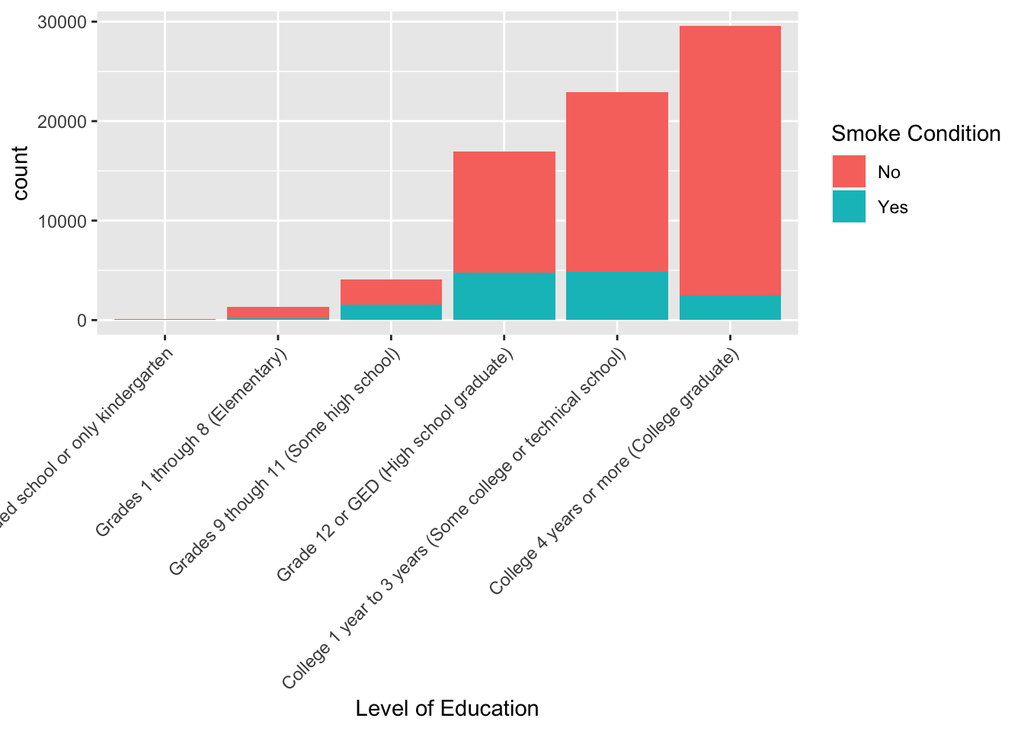

```r
ggplot(question1, aes(x= educa, fill = X_rfsmok3)) + geom_bar() + theme(axis.text.x = element_text(angle = 45,hjust = 1)) + labs( x = "Level of Education",fill ="Smoke Condition")
```

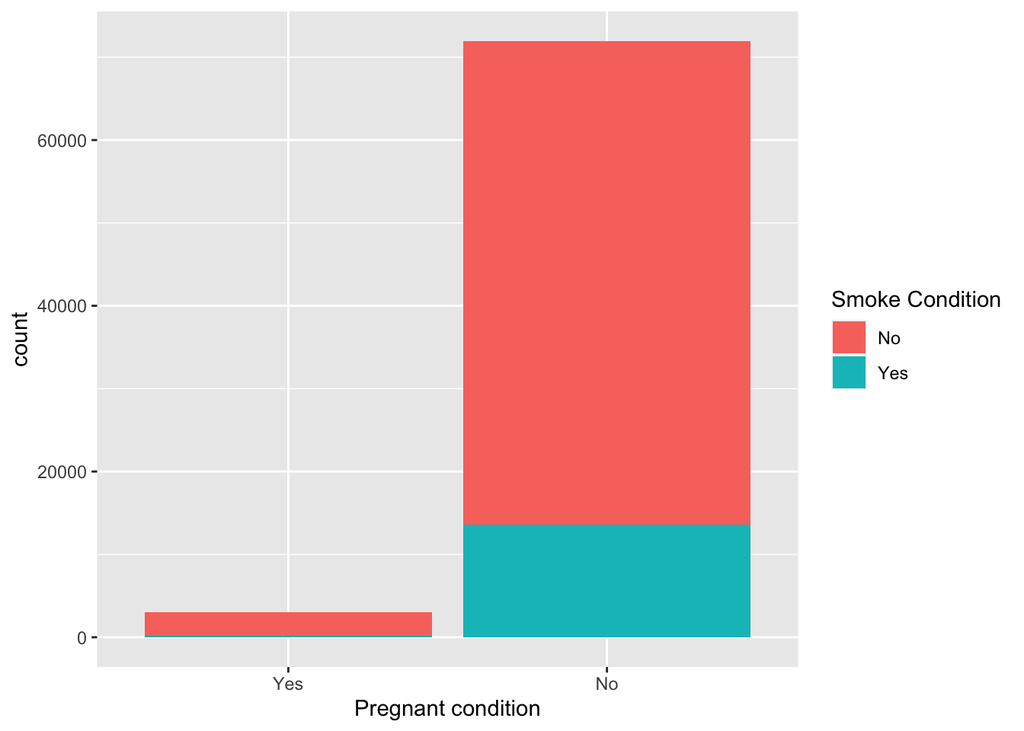

```r
ggplot(question1, aes(x = pregnant, fill = X_rfsmok3)) + geom_bar() + labs( x = "Pregnant condition",fill = "Smoke Condition")
```

Research question 2: Do Alabama people who sleep more feel physical healthier?

First, I need to filter the data of Albama people out from entire state dataset.

```r
question2_alabama <- brfss2013 %>%
filter(X_state == "Alabama")
```

```r
question2 <- question2_alabama %>%
summarise(physhlth,sleptim1) %>%
arrange(-physhlth)
```

Then, as the same, I have to filter out the NA data in both ‘sleptim1’ and ‘physhlth’.

```r
question2 <-question2 %>%
filter(! is.na(physhlth),!is.na(sleptim1))
```

Finally, I use scatterpoint analysis to find the relationship between sleeping time and physical health.

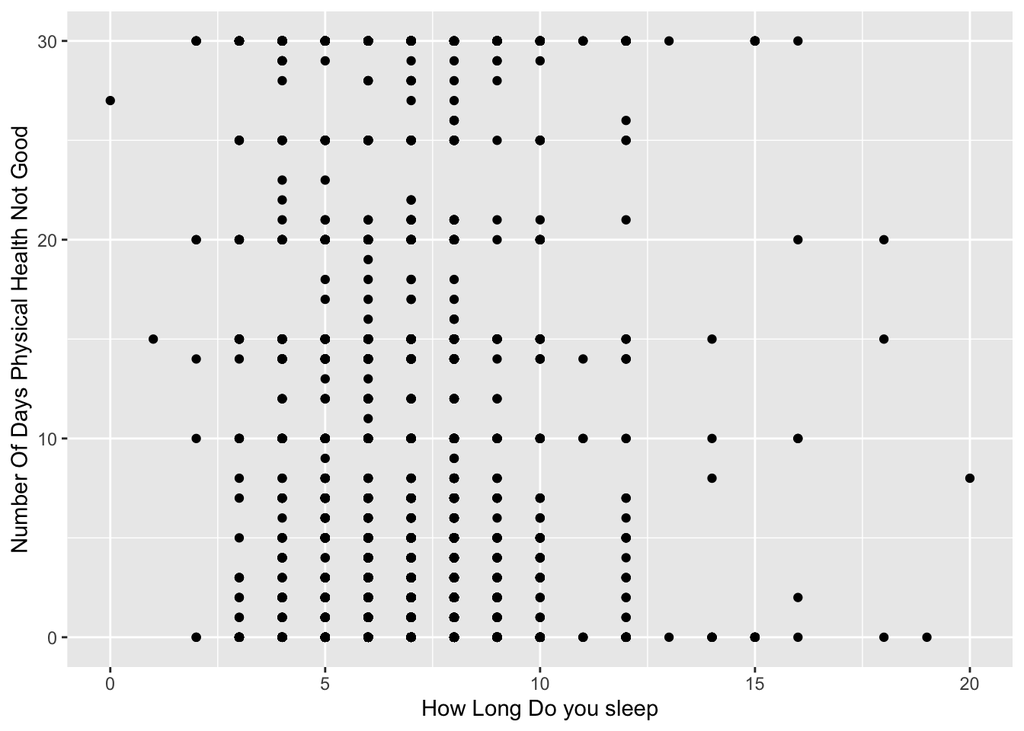

```r
ggplot(question2,aes(x = sleptim1,y = physhlth)) + geom_point() + labs( x = "How Long Do you sleep",  y = "Number Of Days Physical Health Not Good")
```

First, I should select three targeted varibles out of the data cluster. Then I should get rid of NA data and count the rest data into numerical variables.Then I want to see each porportion of three variables when they are formed together.

```r
question3<-brfss2013%>%
filter(!is.na(asattack),!is.na(smoke100),!is.na(poorhlth))%>%
group_by(asattack,smoke100,poorhlth)%>%
summarise(count=n())%>%
mutate(freq=count/sum(count))
knitr::kable(question3[,c("asattack","smoke100", "poorhlth","freq")])
```

| asattack | smoke100 | poorhlth | freq |
| --- | --- | --- | --- |
| Yes | Yes | 0 | 0.2878049 |
| Yes | Yes | 1 | 0.0146341 |
| Yes | Yes | 2 | 0.0146341 |
| Yes | Yes | 3 | 0.0292683 |
| Yes | Yes | 4 | 0.0439024 |
| Yes | Yes | 5 | 0.0195122 |
| Yes | Yes | 6 | 0.0048780 |
| Yes | Yes | 7 | 0.0243902 |
| Yes | Yes | 10 | 0.0682927 |
| Yes | Yes | 14 | 0.0390244 |
| Yes | Yes | 15 | 0.0829268 |
| Yes | Yes | 20 | 0.0536585 |
| Yes | Yes | 21 | 0.0048780 |
| Yes | Yes | 22 | 0.0048780 |
| Yes | Yes | 25 | 0.0341463 |
| Yes | Yes | 27 | 0.0048780 |
| Yes | Yes | 28 | 0.0048780 |
| Yes | Yes | 29 | 0.0048780 |
| Yes | Yes | 30 | 0.2585366 |
| Yes | No | 0 | 0.4401914 |
| Yes | No | 1 | 0.0717703 |
| Yes | No | 2 | 0.0095694 |
| Yes | No | 3 | 0.0382775 |
| Yes | No | 4 | 0.0191388 |
| Yes | No | 5 | 0.0574163 |
| Yes | No | 6 | 0.0095694 |
| Yes | No | 7 | 0.0095694 |
| Yes | No | 10 | 0.0478469 |
| Yes | No | 14 | 0.0191388 |
| Yes | No | 15 | 0.0430622 |
| Yes | No | 16 | 0.0047847 |
| Yes | No | 20 | 0.0622010 |
| Yes | No | 21 | 0.0095694 |
| Yes | No | 25 | 0.0047847 |
| Yes | No | 27 | 0.0047847 |
| Yes | No | 28 | 0.0047847 |
| Yes | No | 30 | 0.1435407 |
| No | Yes | 0 | 0.4255319 |
| No | Yes | 1 | 0.0141844 |
| No | Yes | 2 | 0.0354610 |
| No | Yes | 3 | 0.0354610 |
| No | Yes | 4 | 0.0354610 |
| No | Yes | 5 | 0.0354610 |
| No | Yes | 6 | 0.0070922 |
| No | Yes | 7 | 0.0212766 |
| No | Yes | 8 | 0.0070922 |
| No | Yes | 10 | 0.0070922 |
| No | Yes | 12 | 0.0070922 |
| No | Yes | 14 | 0.0141844 |
| No | Yes | 15 | 0.1063830 |
| No | Yes | 18 | 0.0070922 |
| No | Yes | 20 | 0.0638298 |
| No | Yes | 25 | 0.0070922 |
| No | Yes | 27 | 0.0070922 |
| No | Yes | 30 | 0.1631206 |
| No | No | 0 | 0.5705128 |
| No | No | 1 | 0.0384615 |
| No | No | 2 | 0.0705128 |
| No | No | 3 | 0.0256410 |
| No | No | 4 | 0.0128205 |
| No | No | 5 | 0.0512821 |
| No | No | 6 | 0.0064103 |
| No | No | 7 | 0.0128205 |
| No | No | 10 | 0.0128205 |
| No | No | 14 | 0.0192308 |
| No | No | 15 | 0.0320513 |
| No | No | 20 | 0.0192308 |
| No | No | 23 | 0.0064103 |
| No | No | 30 | 0.1217949 |

Let’s display the data into plots to see if the association is negative. I use both bar chart and boxplot to explain.

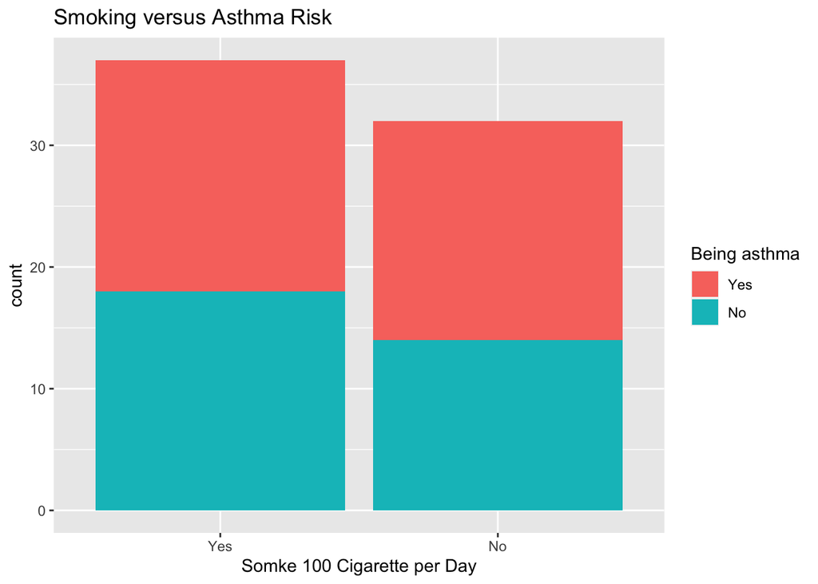

```r
ggplot(question3, aes(x=smoke100, fill = asattack)) +geom_bar()+labs(title="Smoking versus Asthma Risk", x = "Somke 100 Cigarette per Day", fill= "Being asthma")
```

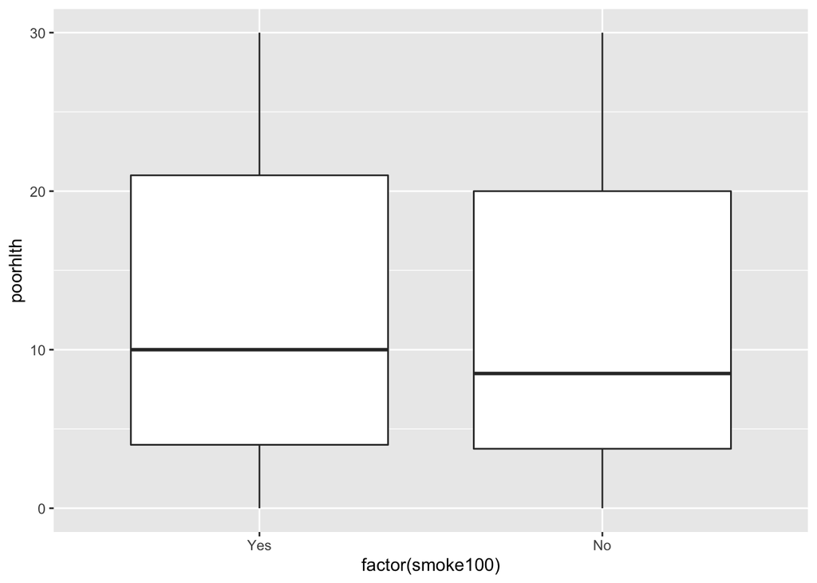

```r
ggplot(question3, aes(x=factor(smoke100), y=poorhlth))+geom_boxplot()
```